# logical flow for bernoulli fission on networks

Daniela Witten

2025-03-21

## Overview

Here are I am making ``real” figures corresponding to the draft figures in this write-up: [https://www.dropbox.com/scl/fi/je353s2aqpppbohqy8tkd/Bernoulli-Data-Fission-logic.pdf?rlkey=pnxtdtq96lbucsnyzkr9nkn35&dl=0]

I AM USING A SUPER SLOPPY VERSION OF SPECTRAL CLUSTERING — NEEDS TO BE FIXED.

## Figures with $M_{ij}$ either 0.2 or 0.8, at random

```r
expit <- function(a){ return(exp(a)/(1+exp(a))) }
logit <- function(a){ return(log(a / (1-a))) }
f <- function(M, v){ return(expit(logit(M) + log(v))) }


niter <- 500
n <- 100
gams <- c(0.01, 0.05, 0.1, 0.2, 0.3, 0.4, 0.5)



Vs.results <- matrix(NA, nrow=length(gams), ncol=niter)
V0s.results <- matrix(NA, nrow=length(gams), ncol=niter)
V1s.results <- matrix(NA, nrow=length(gams), ncol=niter)
V01s.results <- matrix(NA, nrow=length(gams), ncol=niter)
fV0s.results <- matrix(NA, nrow=length(gams), ncol=niter)
fV1s.results <- matrix(NA, nrow=length(gams), ncol=niter)
fV01s.results <- matrix(NA, nrow=length(gams), ncol=niter)
Bs.results <- matrix(NA, nrow=length(gams), ncol=niter)


set.seed(1)


for(gam in gams){
  for(iter in 1:niter){
    M <- matrix(sample(c(0.2,0.8), n*n, rep=TRUE), nrow=n, ncol=n)
    A <- matrix(runif(n*n)<=M, nrow=n, ncol=n)
    W <- matrix(runif(n*n)<=gam, nrow=n, ncol=n)
    Atr <- A*(1-W) + (1-A)*W
    u <- svd(Atr)$u[,1]
    Ztr <- 1*(u>median(u)) # super sloppy version of spectral clustering ... for someone else to fix :)
    if(rnorm(1)>0) Ztr <- 1-Ztr # not sure why this matters
    I11 <- outer(Ztr, Ztr, "*")
    TT <- matrix(NA, nrow=n, ncol=n)
    for(i in which(Ztr==1)){
      for(j in which(Ztr==1)){
        if(Atr[i,j]==1) TT[i,j] <- f(M[i,j], gam/(1-gam))
        if(Atr[i,j]==0) TT[i,j] <- f(M[i,j], (1-gam)/gam)
      }
    }

    Vs.results[gam==gams, iter] <- mean(TT[Ztr==1,Ztr==1])

    V1s.results[gam==gams, iter] <- sum((TT*Atr)[Ztr==1,Ztr==1])/sum(Atr[Ztr==1,Ztr==1])
    V0s.results[gam==gams, iter] <- sum((TT*(1-Atr))[Ztr==1,Ztr==1])/sum(1-Atr[Ztr==1,Ztr==1])

    fV0s.results[gam==gams, iter] <- f(V0s.results[gam==gams, iter], gam/(1-gam))
    fV1s.results[gam==gams, iter] <- f(V1s.results[gam==gams, iter], (1-gam)/gam)

    weight <- (sum(Atr[Ztr==1,Ztr==1])/(sum(Ztr==1)^2))
    fV01s.results[gam==gams, iter] <-  weight*fV1s.results[gam==gams, iter] + (1-weight)*fV0s.results[gam==gams, iter]
    Bs.results[gam==gams,iter] <- mean(M[Ztr==1,Ztr==1])
  }
}
```

This figure shows the problem with using $V_{kl}$ as an estimator of $B_{kl}$:

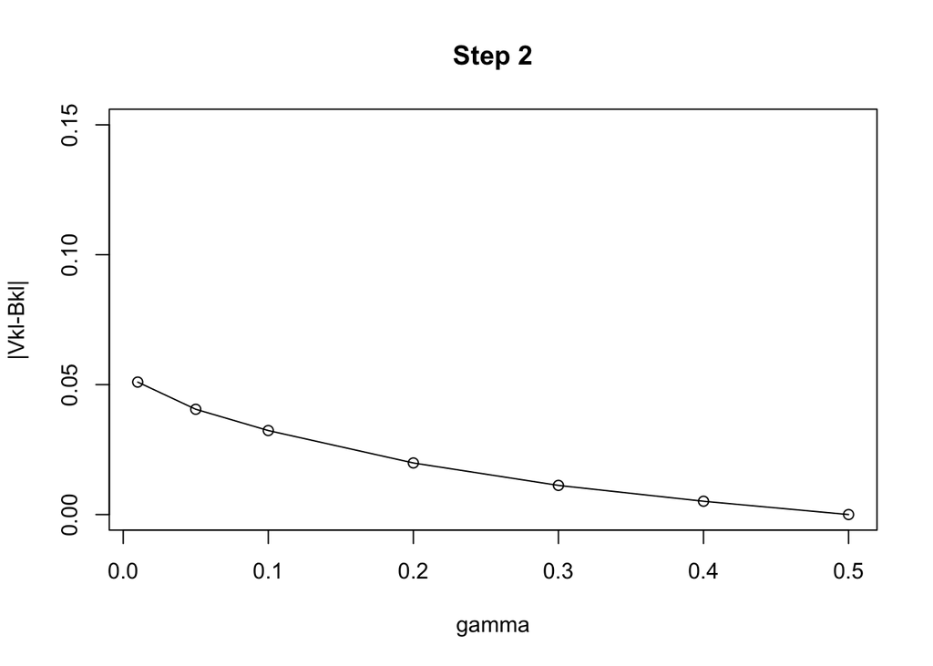

```r
par(mfrow=c(1,1))

plot(gams,apply(abs(Vs.results-Bs.results),1,mean),type="l", xlab="gamma", ylab="|Vkl-Bkl|", main="Step 2", ylim=c(0,0.15))
points(gams, apply(abs(Vs.results-Bs.results),1,mean))
```

We can instead define $V_{kl}^{(0)}$ and $V_{kl}^{(1)}$. These next two plots show results w/ and w/o absolute value signs:

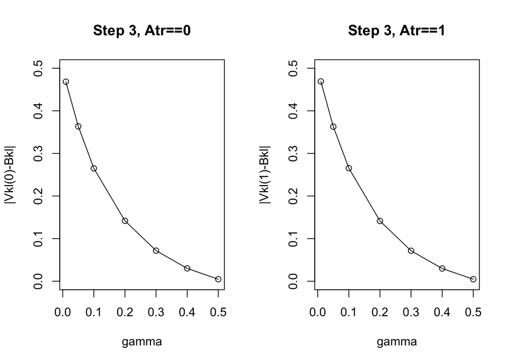

```r
par(mfrow=c(1,2))
plot(gams,apply(abs(V0s.results-Bs.results),1,mean),type="l", xlab="gamma", ylab="|Vkl(0)-Bkl|", main="Step 3, Atr==0", ylim=c(0,0.5))
points(gams, apply(abs(V0s.results-Bs.results),1,mean))


plot(gams,apply(abs(V1s.results-Bs.results),1,mean),type="l", xlab="gamma", ylab="|Vkl(1)-Bkl|", main="Step 3, Atr==1", ylim=c(0,0.5))
points(gams, apply(abs(V1s.results-Bs.results),1,mean))
```

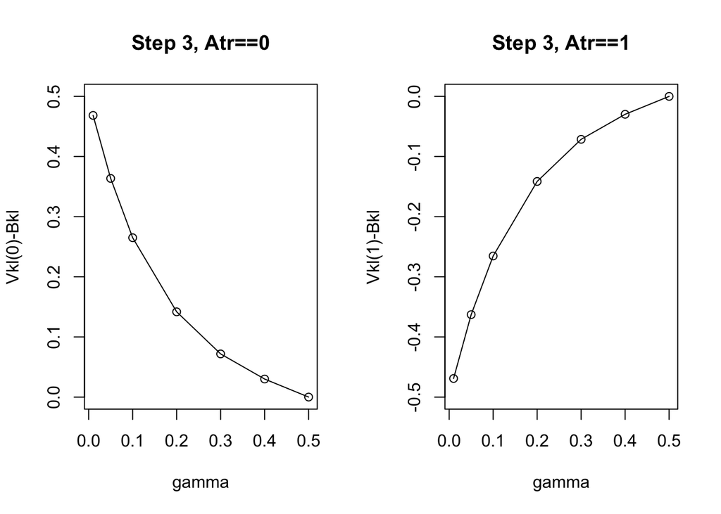

```r
par(mfrow=c(1,2))
plot(gams,apply((V0s.results-Bs.results),1,mean),type="l", xlab="gamma", ylab="Vkl(0)-Bkl", main="Step 3, Atr==0", ylim=c(0,0.5))
points(gams, apply((V0s.results-Bs.results),1,mean))


plot(gams,apply((V1s.results-Bs.results),1,mean),type="l", xlab="gamma", ylab="Vkl(1)-Bkl", main="Step 3, Atr==1", ylim=c(-0.5,0))
points(gams, apply((V1s.results-Bs.results),1,mean))
```

Now let’s transform $V_{kl}^{(0)}$ and $V_{kl}^{(1)}$ to make them closer to $B_{kl}$:

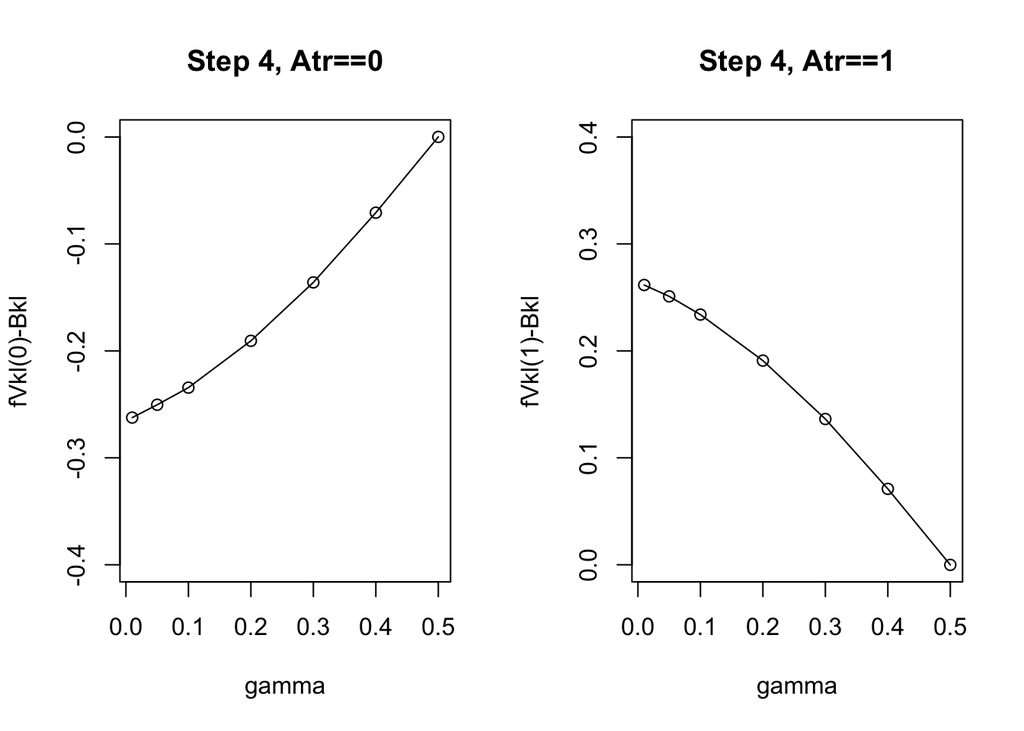

```r
par(mfrow=c(1,2))
plot(gams,apply((fV0s.results-Bs.results),1,mean),type="l", xlab="gamma", ylab="fVkl(0)-Bkl", main="Step 4, Atr==0", ylim=c(-0.4,0))
points(gams, apply((fV0s.results-Bs.results),1,mean))

plot(gams,apply((fV1s.results-Bs.results),1,mean),type="l", xlab="gamma", ylab="fVkl(1)-Bkl", main="Step 4, Atr==1", ylim=c(0,0.4))
points(gams, apply((fV1s.results-Bs.results),1,mean))
```

And we can take the linear combination of those two little muffins:

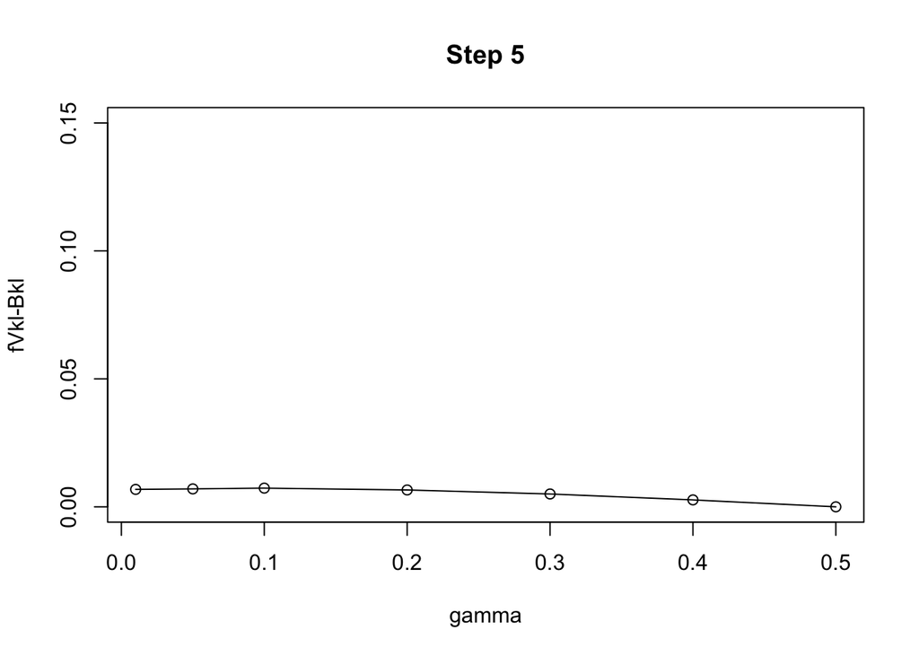

```r
plot(gams,apply(abs(fV01s.results-Bs.results),1,mean),type="l", xlab="gamma", ylab="fVkl-Bkl", main="Step 5", ylim=c(0,0.15))
points(gams, apply(abs(fV01s.results-Bs.results),1,mean))
```

Now a single figure for paper:

```r
pdf("fig-M-random.pdf", width=3, height=3)
par(mar=c(4,2,0.4,0.4))
plot(gams,apply(abs(fV01s.results-Bs.results),1,mean),type="l", xlab=expression(gamma),  ylab="",  ylim=c(0,0.06))
points(gams, apply(abs(fV01s.results-Bs.results),1,mean))
lines(gams,apply(abs(Vs.results-Bs.results),1,mean), col="blue")#,type="l", xlab="gamma", ylab="fVkl-Bkl", main="Step 5", ylim=c(0,0.5))
points(gams, apply(abs(Vs.results-Bs.results),1,mean), col="blue")

#legend("topright", pch=15, col=c("blue", "black"), c("|Vkl-Bkl|", "|Phikl-Bkl|"))
dev.off()
```

## Figures with $M_{ij}$ following an SBM:

```r
Vs.results <- matrix(NA, nrow=length(gams), ncol=niter)
V0s.results <- matrix(NA, nrow=length(gams), ncol=niter)
V1s.results <- matrix(NA, nrow=length(gams), ncol=niter)
V01s.results <- matrix(NA, nrow=length(gams), ncol=niter)
fV0s.results <- matrix(NA, nrow=length(gams), ncol=niter)
fV1s.results <- matrix(NA, nrow=length(gams), ncol=niter)
fV01s.results <- matrix(NA, nrow=length(gams), ncol=niter)
Bs.results <- matrix(NA, nrow=length(gams), ncol=niter)
for(gam in gams){
  for(iter in 1:niter){
    M <- matrix(0, nrow=n, ncol=n)
    M[1:(n/2), 1:(n/2)] <- 0.3
    M[n/2 + 1:(n/2), n/2 + 1:(n/2)] <- 0.7
    A <- matrix(runif(n*n)<=M, nrow=n, ncol=n)
    W <- matrix(runif(n*n)<=gam, nrow=n, ncol=n)
    Atr <- A*(1-W) + (1-A)*W
    u <- svd(Atr)$u[,1]
    Ztr <- 1*(u>median(u)) # super sloppy version of spectral clustering ... for someone else to fix :)
    if(rnorm(1)>0) Ztr <- 1-Ztr # not sure why this matters
    I11 <- outer(Ztr, Ztr, "*")
    TT <- matrix(NA, nrow=n, ncol=n)
    for(i in which(Ztr==1)){
      for(j in which(Ztr==1)){
        if(Atr[i,j]==1) TT[i,j] <- f(M[i,j], gam/(1-gam))
        if(Atr[i,j]==0) TT[i,j] <- f(M[i,j], (1-gam)/gam)
      }
    }

    Vs.results[gam==gams, iter] <- mean(TT[Ztr==1,Ztr==1])

    V1s.results[gam==gams, iter] <- sum((TT*Atr)[Ztr==1,Ztr==1])/sum(Atr[Ztr==1,Ztr==1])
    V0s.results[gam==gams, iter] <- sum((TT*(1-Atr))[Ztr==1,Ztr==1])/sum(1-Atr[Ztr==1,Ztr==1])

    fV0s.results[gam==gams, iter] <- f(V0s.results[gam==gams, iter], gam/(1-gam))
    fV1s.results[gam==gams, iter] <- f(V1s.results[gam==gams, iter], (1-gam)/gam)

    weight <- (sum(Atr[Ztr==1,Ztr==1])/(sum(Ztr==1)^2))
    fV01s.results[gam==gams, iter] <-  weight*fV1s.results[gam==gams, iter] + (1-weight)*fV0s.results[gam==gams, iter]
    Bs.results[gam==gams,iter] <- mean(M[Ztr==1,Ztr==1])
  }
}
```

This figure shows the problem with using $V_{kl}$ as an estimator of $B_{kl}$:

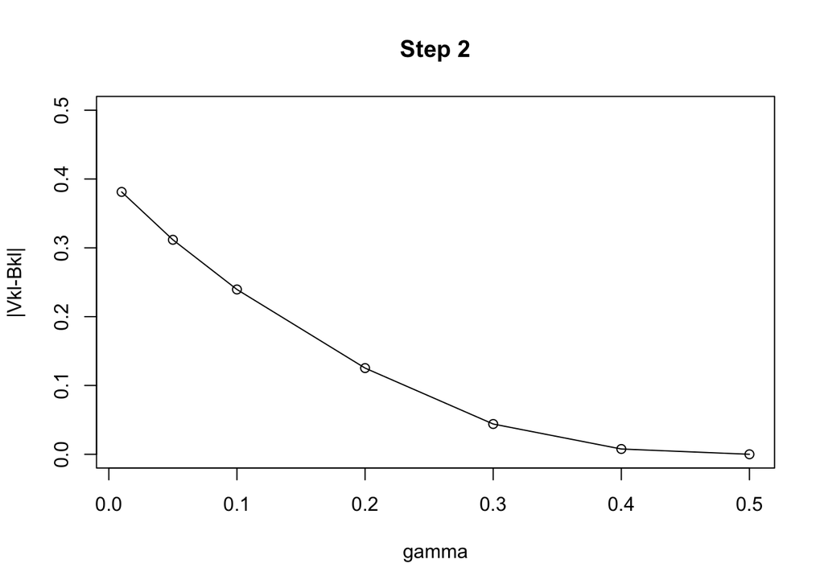

```r
par(mfrow=c(1,1))

plot(gams,apply(abs(Vs.results-Bs.results),1,mean),type="l", xlab="gamma", ylab="|Vkl-Bkl|", main="Step 2", ylim=c(0,0.5))
points(gams, apply(abs(Vs.results-Bs.results),1,mean))
```

We can instead define $V_{kl}^{(0)}$ and $V_{kl}^{(1)}$. These next two plots show results w/ and w/o absolute value signs:

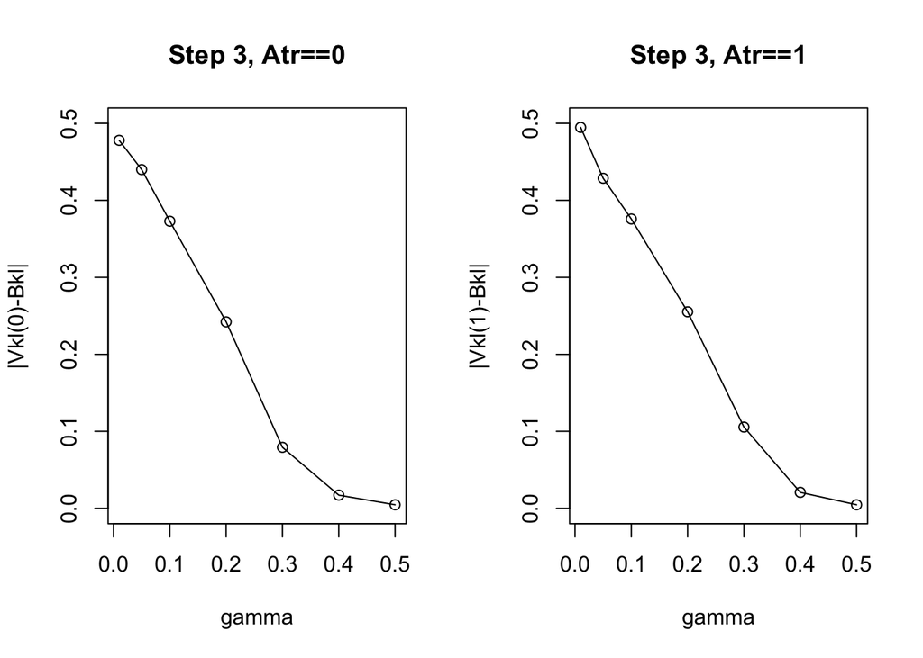

```r
par(mfrow=c(1,2))
plot(gams,apply(abs(V0s.results-Bs.results),1,mean),type="l", xlab="gamma", ylab="|Vkl(0)-Bkl|", main="Step 3, Atr==0", ylim=c(0,0.5))
points(gams, apply(abs(V0s.results-Bs.results),1,mean))


plot(gams,apply(abs(V1s.results-Bs.results),1,mean),type="l", xlab="gamma", ylab="|Vkl(1)-Bkl|", main="Step 3, Atr==1", ylim=c(0,0.5))
points(gams, apply(abs(V1s.results-Bs.results),1,mean))
```

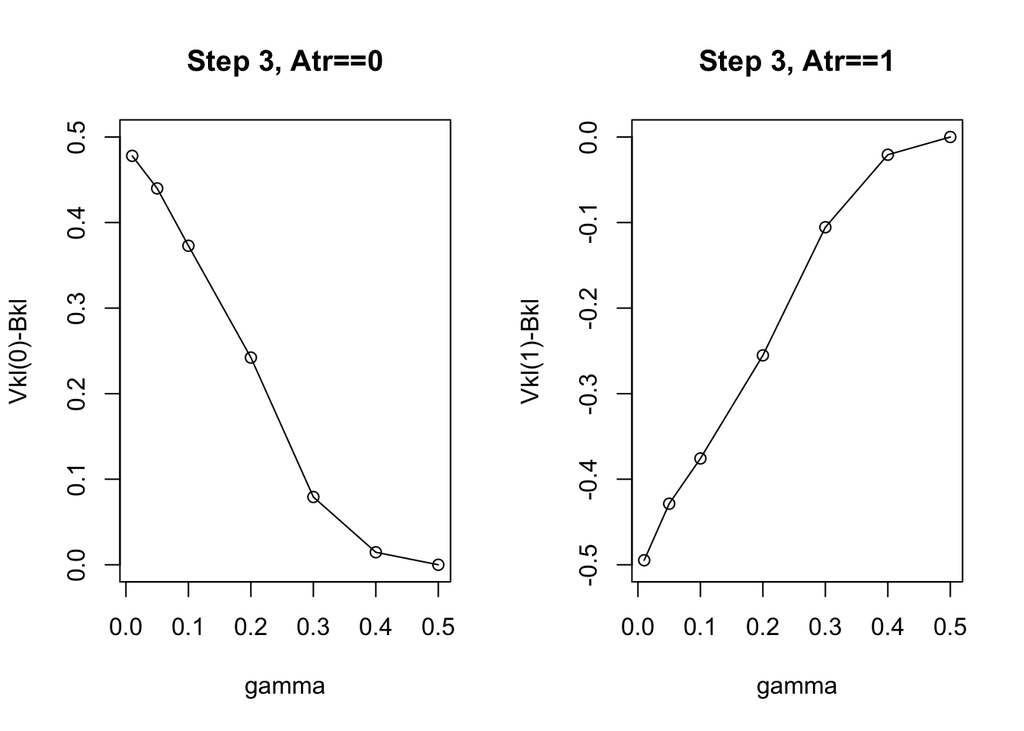

```r
par(mfrow=c(1,2))
plot(gams,apply((V0s.results-Bs.results),1,mean),type="l", xlab="gamma", ylab="Vkl(0)-Bkl", main="Step 3, Atr==0", ylim=c(0,0.5))
points(gams, apply((V0s.results-Bs.results),1,mean))


plot(gams,apply((V1s.results-Bs.results),1,mean),type="l", xlab="gamma", ylab="Vkl(1)-Bkl", main="Step 3, Atr==1", ylim=c(-0.5,0))
points(gams, apply((V1s.results-Bs.results),1,mean))
```

Now let’s transform $V_{kl}^{(0)}$ and $V_{kl}^{(1)}$ to make them closer to $B_{kl}$:

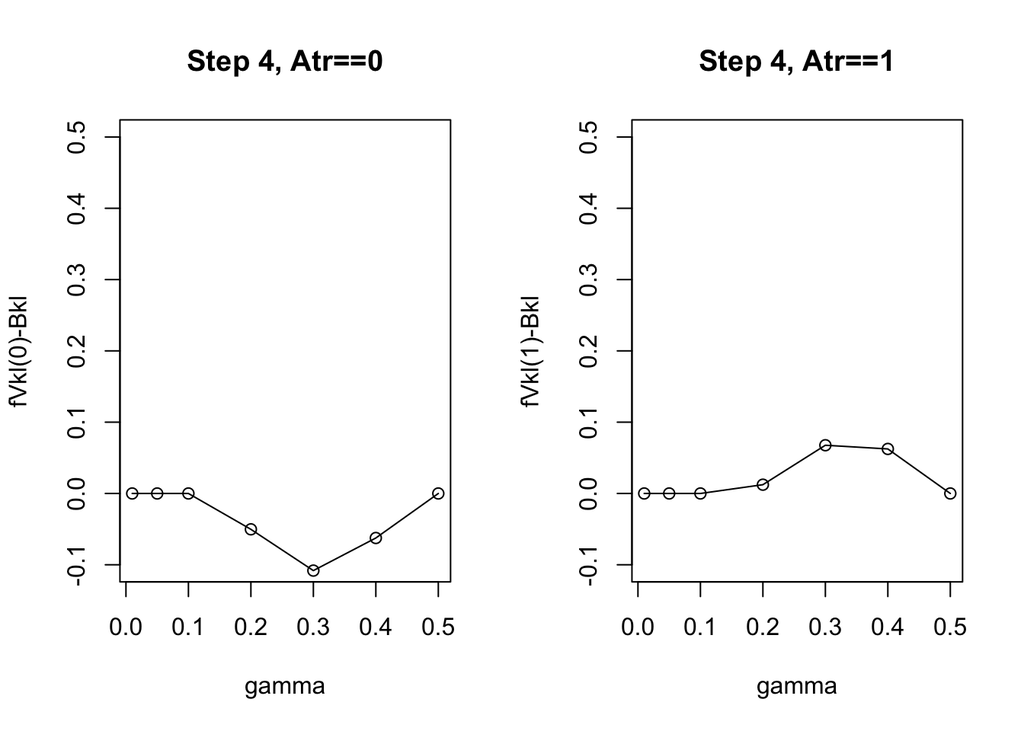

```r
par(mfrow=c(1,2))
plot(gams,apply((fV0s.results-Bs.results),1,mean),type="l", xlab="gamma", ylab="fVkl(0)-Bkl", main="Step 4, Atr==0", ylim=c(-0.1,0.5))
points(gams, apply((fV0s.results-Bs.results),1,mean))

plot(gams,apply((fV1s.results-Bs.results),1,mean),type="l", xlab="gamma", ylab="fVkl(1)-Bkl", main="Step 4, Atr==1", ylim=c(-0.1,0.5))
points(gams, apply((fV1s.results-Bs.results),1,mean))
```

And we can take the linear combination of those two little muffins:

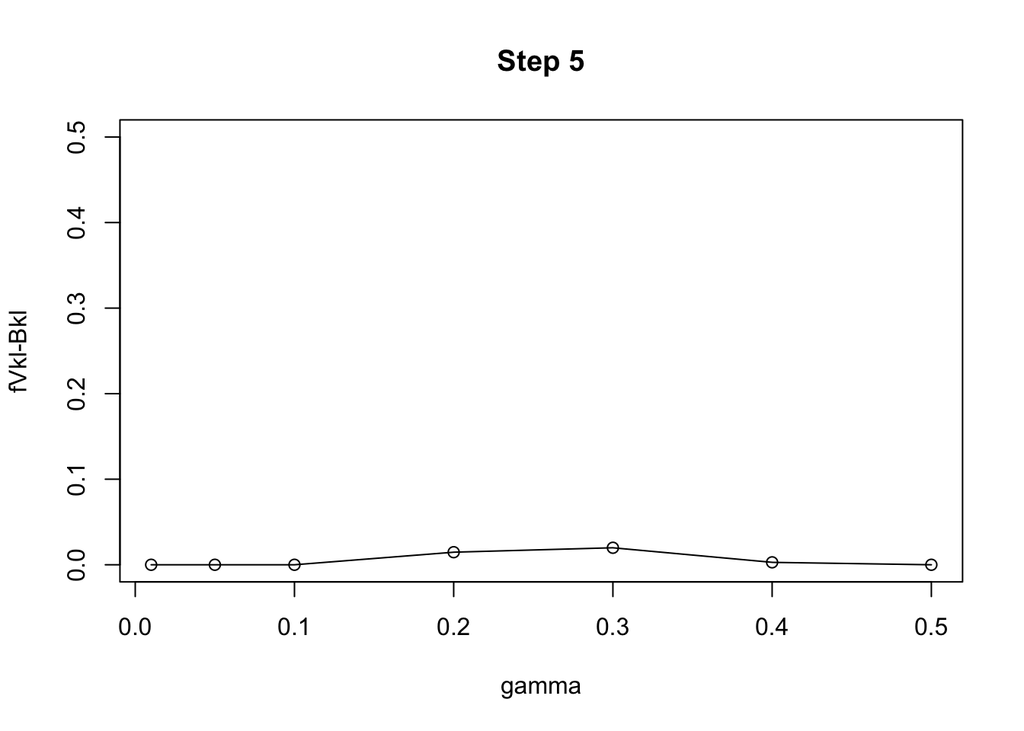

```r
plot(gams,apply(abs(fV01s.results-Bs.results),1,mean),type="l", xlab="gamma", ylab="fVkl-Bkl", main="Step 5", ylim=c(0,0.5))
points(gams, apply(abs(fV01s.results-Bs.results),1,mean))
```

Now a single figure for paper:

```r
pdf("fig-M-sbm.pdf", width=3, height=3)
par(mar=c(4,2,0.4,0.4))
plot(gams,apply(abs(fV01s.results-Bs.results),1,mean),type="l", xlab=expression(gamma), ylab="", ylim=c(0,0.5))
points(gams, apply(abs(fV01s.results-Bs.results),1,mean))
lines(gams,apply(abs(Vs.results-Bs.results),1,mean), col="blue")#,type="l", xlab="gamma", ylab="fVkl-Bkl", main="Step 5", ylim=c(0,0.5))
points(gams, apply(abs(Vs.results-Bs.results),1,mean), col="blue")
#legend("topright", pch=15, col=c("blue", "black"), c("|Vkl-Bkl|", "|Phikl-Bkl|"))
dev.off()
```

## Figures with M=0.5:

```r
Vs.results <- matrix(NA, nrow=length(gams), ncol=niter)
V0s.results <- matrix(NA, nrow=length(gams), ncol=niter)
V1s.results <- matrix(NA, nrow=length(gams), ncol=niter)
V01s.results <- matrix(NA, nrow=length(gams), ncol=niter)
fV0s.results <- matrix(NA, nrow=length(gams), ncol=niter)
fV1s.results <- matrix(NA, nrow=length(gams), ncol=niter)
fV01s.results <- matrix(NA, nrow=length(gams), ncol=niter)
Bs.results <- matrix(NA, nrow=length(gams), ncol=niter)
for(gam in gams){
  for(iter in 1:niter){
    M <- matrix(0.5, nrow=n, ncol=n)
 #   M[1:(n/2), 1:(n/2)] <- 0.3
 #   M[n/2 + 1:(n/2), n/2 + 1:(n/2)] <- 0.7
    A <- matrix(runif(n*n)<=M, nrow=n, ncol=n)
    W <- matrix(runif(n*n)<=gam, nrow=n, ncol=n)
    Atr <- A*(1-W) + (1-A)*W
    u <- svd(Atr)$u[,1]
    Ztr <- 1*(u>median(u)) # super sloppy version of spectral clustering ... for someone else to fix :)
    if(rnorm(1)>0) Ztr <- 1-Ztr # not sure why this matters
    I11 <- outer(Ztr, Ztr, "*")
    TT <- matrix(NA, nrow=n, ncol=n)
    for(i in which(Ztr==1)){
      for(j in which(Ztr==1)){
        if(Atr[i,j]==1) TT[i,j] <- f(M[i,j], gam/(1-gam))
        if(Atr[i,j]==0) TT[i,j] <- f(M[i,j], (1-gam)/gam)
      }
    }

    Vs.results[gam==gams, iter] <- mean(TT[Ztr==1,Ztr==1])

    V1s.results[gam==gams, iter] <- sum((TT*Atr)[Ztr==1,Ztr==1])/sum(Atr[Ztr==1,Ztr==1])
    V0s.results[gam==gams, iter] <- sum((TT*(1-Atr))[Ztr==1,Ztr==1])/sum(1-Atr[Ztr==1,Ztr==1])

    fV0s.results[gam==gams, iter] <- f(V0s.results[gam==gams, iter], gam/(1-gam))
    fV1s.results[gam==gams, iter] <- f(V1s.results[gam==gams, iter], (1-gam)/gam)

    weight <- (sum(Atr[Ztr==1,Ztr==1])/(sum(Ztr==1)^2))
    fV01s.results[gam==gams, iter] <-  weight*fV1s.results[gam==gams, iter] + (1-weight)*fV0s.results[gam==gams, iter]
    Bs.results[gam==gams,iter] <- mean(M[Ztr==1,Ztr==1])
  }
}
```

This figure shows the problem with using $V_{kl}$ as an estimator of $B_{kl}$:

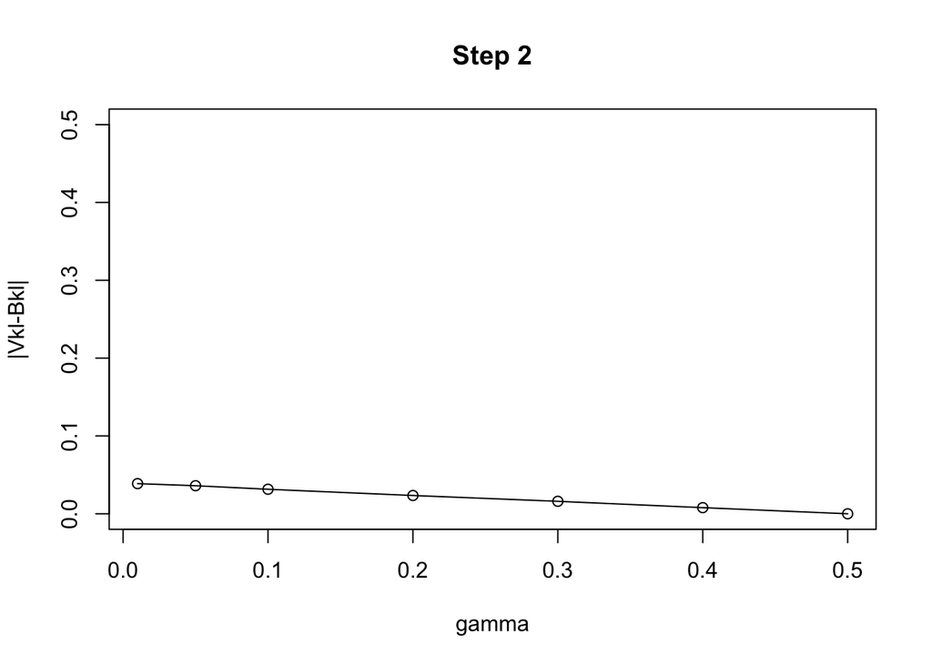

```r
par(mfrow=c(1,1))

plot(gams,apply(abs(Vs.results-Bs.results),1,mean),type="l", xlab="gamma", ylab="|Vkl-Bkl|", main="Step 2", ylim=c(0,0.5))
points(gams, apply(abs(Vs.results-Bs.results),1,mean))
```

We can instead define $V_{kl}^{(0)}$ and $V_{kl}^{(1)}$. These next two plots show results w/ and w/o absolute value signs:

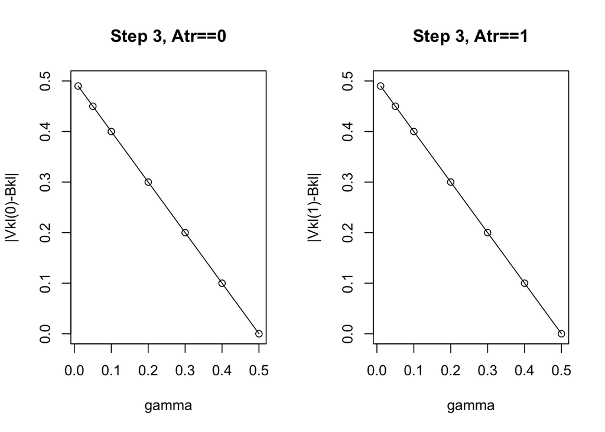

```r
par(mfrow=c(1,2))
plot(gams,apply(abs(V0s.results-Bs.results),1,mean),type="l", xlab="gamma", ylab="|Vkl(0)-Bkl|", main="Step 3, Atr==0", ylim=c(0,0.5))
points(gams, apply(abs(V0s.results-Bs.results),1,mean))


plot(gams,apply(abs(V1s.results-Bs.results),1,mean),type="l", xlab="gamma", ylab="|Vkl(1)-Bkl|", main="Step 3, Atr==1", ylim=c(0,0.5))
points(gams, apply(abs(V1s.results-Bs.results),1,mean))
```

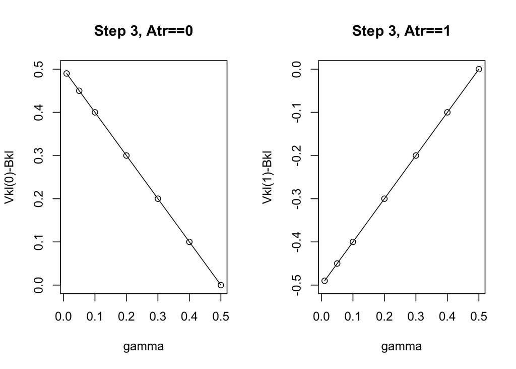

```r
par(mfrow=c(1,2))
plot(gams,apply((V0s.results-Bs.results),1,mean),type="l", xlab="gamma", ylab="Vkl(0)-Bkl", main="Step 3, Atr==0", ylim=c(0,0.5))
points(gams, apply((V0s.results-Bs.results),1,mean))


plot(gams,apply((V1s.results-Bs.results),1,mean),type="l", xlab="gamma", ylab="Vkl(1)-Bkl", main="Step 3, Atr==1", ylim=c(-0.5,0))
points(gams, apply((V1s.results-Bs.results),1,mean))
```

Now let’s transform $V_{kl}^{(0)}$ and $V_{kl}^{(1)}$ to make them closer to $B_{kl}$:

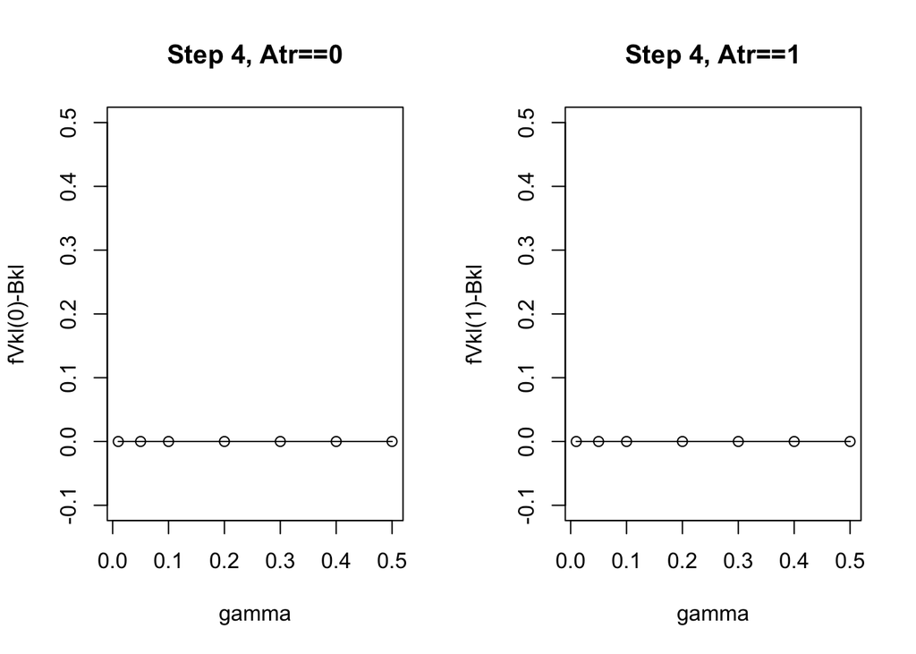

```r
par(mfrow=c(1,2))
plot(gams,apply((fV0s.results-Bs.results),1,mean),type="l", xlab="gamma", ylab="fVkl(0)-Bkl", main="Step 4, Atr==0", ylim=c(-0.1,0.5))
points(gams, apply((fV0s.results-Bs.results),1,mean))

plot(gams,apply((fV1s.results-Bs.results),1,mean),type="l", xlab="gamma", ylab="fVkl(1)-Bkl", main="Step 4, Atr==1", ylim=c(-0.1,0.5))
points(gams, apply((fV1s.results-Bs.results),1,mean))
```

And we can take the linear combination of those two little muffins:

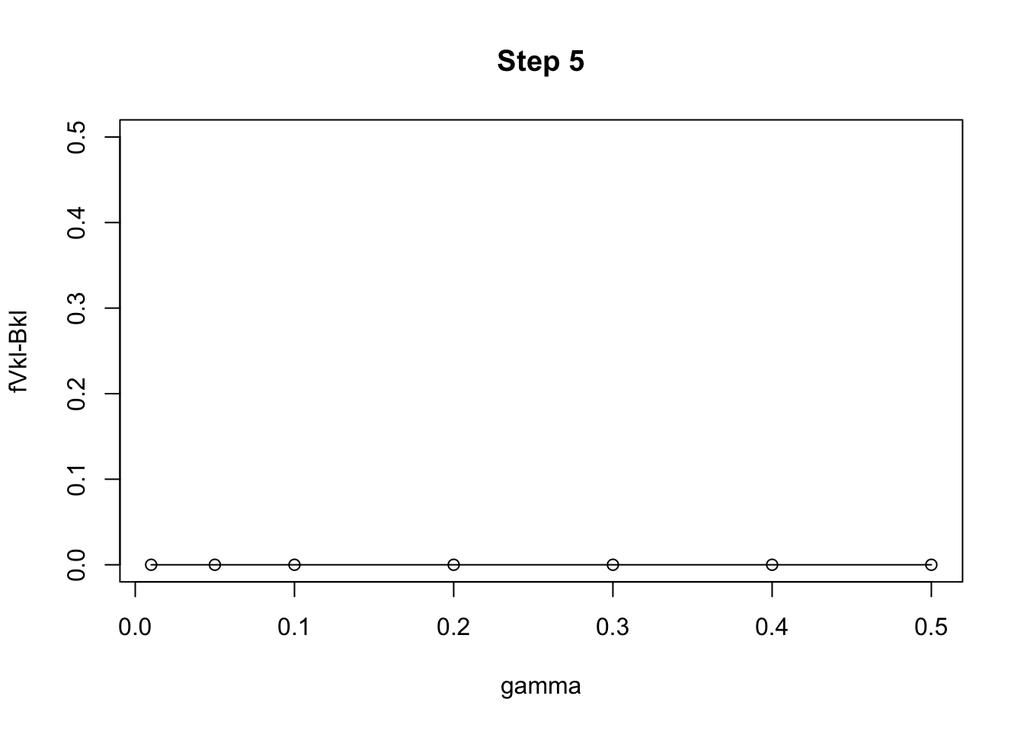

```r
plot(gams,apply(abs(fV01s.results-Bs.results),1,mean),type="l", xlab="gamma", ylab="fVkl-Bkl", main="Step 5", ylim=c(0,0.5))
points(gams, apply(abs(fV01s.results-Bs.results),1,mean))
```

Now a single figure for paper:

```r
pdf("fig-M-constant.pdf", width=3, height=3)
par(mar=c(4,2,0.4,0.4))
plot(gams,apply(abs(fV01s.results-Bs.results),1,mean),type="l", xlab=expression(gamma),  ylab="",  ylim=c(0,0.045))
points(gams, apply(abs(fV01s.results-Bs.results),1,mean))
lines(gams,apply(abs(Vs.results-Bs.results),1,mean), col="blue")#,type="l", xlab="gamma", ylab="fVkl-Bkl", main="Step 5", ylim=c(0,0.5))
points(gams, apply(abs(Vs.results-Bs.results),1,mean), col="blue")
#legend("topright", pch=15, col=c("blue", "black"), c("|Vkl-Bkl|", "|Phikl-Bkl|"))
dev.off()
```